# Extreme gradient boosting

```python
import pandas as pd
import numpy as np
from sklearn.model_selection import train_test_split
from sklearn.metrics import mean_squared_error
housing = pd.read_csv('/Users/shivampandey/Downloads/python files/datasets/housing.csv')
```

I am using housing data to train my model using XGBOOST.This housing data is different from the Boston housing data. I have already preprocessed this dataset and I am just concentrating to build a model that predict with great accuracy.

```python
housing.head()
```

|  | MSSubClass | LotFrontage | LotArea | OverallQual | OverallCond | YearBuilt | Remodeled | GrLivArea | BsmtFullBath | BsmtHalfBath | ... | HouseStyle_1.5Unf | HouseStyle_1Story | HouseStyle_2.5Fin | HouseStyle_2.5Unf | HouseStyle_2Story | HouseStyle_SFoyer | HouseStyle_SLvl | PavedDrive_P | PavedDrive_Y | SalePrice |
| --- | --- | --- | --- | --- | --- | --- | --- | --- | --- | --- | --- | --- | --- | --- | --- | --- | --- | --- | --- | --- | --- |
| 0 | 60 | 65.0 | 8450 | 7 | 5 | 2003 | 0 | 1710 | 1 | 0 | ... | 0 | 0 | 0 | 0 | 1 | 0 | 0 | 0 | 1 | 208500 |
| 1 | 20 | 80.0 | 9600 | 6 | 8 | 1976 | 0 | 1262 | 0 | 1 | ... | 0 | 1 | 0 | 0 | 0 | 0 | 0 | 0 | 1 | 181500 |
| 2 | 60 | 68.0 | 11250 | 7 | 5 | 2001 | 1 | 1786 | 1 | 0 | ... | 0 | 0 | 0 | 0 | 1 | 0 | 0 | 0 | 1 | 223500 |
| 3 | 70 | 60.0 | 9550 | 7 | 5 | 1915 | 1 | 1717 | 1 | 0 | ... | 0 | 0 | 0 | 0 | 1 | 0 | 0 | 0 | 1 | 140000 |
| 4 | 60 | 84.0 | 14260 | 8 | 5 | 2000 | 0 | 2198 | 1 | 0 | ... | 0 | 0 | 0 | 0 | 1 | 0 | 0 | 0 | 1 | 250000 |

5 rows × 57 columns

```python
import xgboost as xgb
```

```python
X , y = housing.iloc[:,:-1],housing.iloc[:,-1]
```

```python
X_train,X_test,y_train,y_test = train_test_split(X,y,test_size = 0.2,random_state = 42)
```

```python
xgb_reg = xgb.XGBRegressor(objective='reg:linear' , n_estimators = 10 , seed = 10)
```

```python
xgb_reg.fit(X_train,y_train)
```

```
XGBRegressor(base_score=0.5, booster='gbtree', colsample_bylevel=1,
       colsample_bytree=1, gamma=0, learning_rate=0.1, max_delta_step=0,
       max_depth=3, min_child_weight=1, missing=None, n_estimators=10,
       n_jobs=1, nthread=None, objective='reg:linear', random_state=0,
       reg_alpha=0, reg_lambda=1, scale_pos_weight=1, seed=10, silent=True,
       subsample=1)
```

```python
pred = xgb_reg.predict(X_test)
```

```python
rmse = np.sqrt(mean_squared_error(y_test , pred))
print("RMSE : %f" % (rmse))
```

```
RMSE : 81809.661276
```

XGBoost gets its lauded performance and efficiency gains by utilizing its own optimized data structure for datasets called a DMatrix. Above,the input datasets were converted into DMatrix data on the fly, but when use the xgboost cv object, first explicitly convert data into a DMatrix.

```python
house_data = xgb.DMatrix(data = X , label = y)
```

```python
print(house_data)
```

```
<xgboost.core.DMatrix object at 0x10d4c5630>
```

```python
params = {'objective':'reg:linear' , 'max_depth': 4}

cross_val = xgb.cv(dtrain = house_data , nfold = 3 , params = params , num_boost_round = 5 , metrics = 'rmse' ,
                   as_pandas = True ,seed = 42)
```

params is parameter dictionary, folds is the number of cross-validation folds num_boosting_rounds is the number of trees want to build metrics is the metric want to compute (this will be "rmse")

```python
print(cross_val)
```

```
   train-rmse-mean  train-rmse-std  test-rmse-mean  test-rmse-std
0    141822.213542      868.807776   142707.984375    1936.936808
1    102985.067708      618.105884   104897.380208    2053.458730
2     75895.000000      511.218940    79172.619791    2676.645382
3     57180.027344      392.449649    62472.852864    3024.894172
4     44301.024740      219.282196    51888.635417    3057.305005
```

Lets try linear base model of XGboost This model, although not as commonly used in XGBoost, allows to create a regularized linear regression using XGBoost's powerful learning API. However, because it's uncommon, so its important to use XGBoost's own non-scikit-learn compatible functions to build the model, such as xgb.train(). The key-value pair that defines the booster type (base model) is "booster":"gblinear".

```python
dm_train = xgb.DMatrix(data = X_train , label = y_train)
dm_test = xgb.DMatrix(data = X_test , label = y_test)
```

```python
params = {'booster':'gblinear' , 'objective':'reg:linear'}
```

```python
xg_reg = xgb.train(params = params , dtrain = dm_train , num_boost_round = 5)
```

```python
pred = xg_reg.predict(dm_test)
```

```python
rmse = np.sqrt(mean_squared_error(y_test,pred))
print("RMSE: %f" % (rmse))
```

```
RMSE: 47249.726184
```

it looks like linear base learners performed better

Regulariztion in XGBoost to check the model complexity.

```python
house_data = xgb.DMatrix(data = X , label = y)
reg_params = [1,10,100]

params = {"objective":"reg:linear","max_depth":3}

rmses_l2 = [] # l2 regularization penalty - also known as "lambda"

for reg in reg_params:

    params["lambda"] = reg

    cv_results_rmse = xgb.cv(dtrain=house_data, params=params, nfold=2, num_boost_round=5,
                             metrics="rmse", as_pandas=True, seed=42)

    rmses_l2.append(cv_results_rmse["test-rmse-mean"].tail(1).values[0])
```

```python
print("Best rmse as a function of alpha l2:")
print(reg_params,rmses_l2)
```

```
Best rmse as a function of alpha l2:
[1, 10, 100] [51779.6132815, 57648.78125, 77064.535156]
```

```python
print(pd.DataFrame(list(zip(reg_params,rmses_l2)),columns = ['best_params' , 'rmse_l2']))
```

```
   best_params       rmse_l2
0            1  51779.613282
1           10  57648.781250
2          100  77064.535156
```

It looks like as the value of 'lambda' increases, so does the RMSE.

```python
Visualizing feature importances: What features are most important in my dataset
XGBoost has a plot_importance() function that allows to do exactly this
```

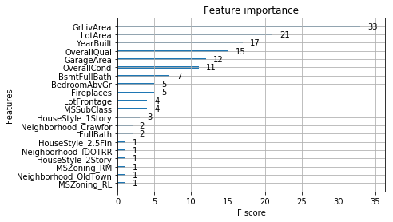

```python
import matplotlib.pyplot as plt

# Create the parameter dictionary: params
params = {"objective":"reg:linear", "max_depth":4}

# Train the model: xg_reg
xg_reg = xgb.train(params = params, dtrain = house_data, num_boost_round = 10)

# Plot the feature importances
xgb.plot_importance(xg_reg)
plt.show()
```

These are the important features of this dataset.Xgboost has its own plot_importance function which help to know what features to take or vice versa.

Well i am just wondering to know the difference between tuned and untuned model.

```python
#untuned model.
housing.head()
```

|  | MSSubClass | LotFrontage | LotArea | OverallQual | OverallCond | YearBuilt | Remodeled | GrLivArea | BsmtFullBath | BsmtHalfBath | ... | HouseStyle_1.5Unf | HouseStyle_1Story | HouseStyle_2.5Fin | HouseStyle_2.5Unf | HouseStyle_2Story | HouseStyle_SFoyer | HouseStyle_SLvl | PavedDrive_P | PavedDrive_Y | SalePrice |
| --- | --- | --- | --- | --- | --- | --- | --- | --- | --- | --- | --- | --- | --- | --- | --- | --- | --- | --- | --- | --- | --- |
| 0 | 60 | 65.0 | 8450 | 7 | 5 | 2003 | 0 | 1710 | 1 | 0 | ... | 0 | 0 | 0 | 0 | 1 | 0 | 0 | 0 | 1 | 208500 |
| 1 | 20 | 80.0 | 9600 | 6 | 8 | 1976 | 0 | 1262 | 0 | 1 | ... | 0 | 1 | 0 | 0 | 0 | 0 | 0 | 0 | 1 | 181500 |
| 2 | 60 | 68.0 | 11250 | 7 | 5 | 2001 | 1 | 1786 | 1 | 0 | ... | 0 | 0 | 0 | 0 | 1 | 0 | 0 | 0 | 1 | 223500 |
| 3 | 70 | 60.0 | 9550 | 7 | 5 | 1915 | 1 | 1717 | 1 | 0 | ... | 0 | 0 | 0 | 0 | 1 | 0 | 0 | 0 | 1 | 140000 |
| 4 | 60 | 84.0 | 14260 | 8 | 5 | 2000 | 0 | 2198 | 1 | 0 | ... | 0 | 0 | 0 | 0 | 1 | 0 | 0 | 0 | 1 | 250000 |

5 rows × 57 columns

```python
X,y = housing[housing.columns.tolist()[:-1]],housing[housing.columns.tolist()[-1]]
```

```python
print(type(X),type(y))
```

```
<class 'pandas.core.frame.DataFrame'> <class 'pandas.core.series.Series'>
```

```python
housingdmatrix = xgb.DMatrix(data = X,label = y)
```

```python
params = {'objective':'reg:linear'}

cv_untuned = xgb.cv(dtrain = housingdmatrix , params = params , metrics  = 'rmse' , seed = 42 , nfold = 4,
                    as_pandas = True)
```

```python
print("Untuned rmse: %f" %((cv_untuned['test-rmse-mean']).tail(1)))
```

```
Untuned rmse: 32046.558593
```

```python
#Tuned model
```

```python
tuned_params = {"objective":"reg:linear","learning_rate":0.1 , "max_depth":5 , "colsample_bytree":0.3}

cv_tuned = xgb.cv(dtrain = housingdmatrix , params = tuned_params , nfold = 4 , num_boost_round = 200 , seed = 42,
                 as_pandas = True , metrics = 'rmse')
```

```python
print("Tuned rmse: %f " %((cv_tuned['test-rmse-mean']).tail(1)))
```

```
Tuned rmse: 27550.453125
```

The difference between tuned and untuned model is matters a lot and it is visible from the rmse score.

In xgboost model there are many tree tunable parameters.like gamma,lambda l2,alpha l1,subsample,colsample_bytree,learning rate(eta).so i am going to tune there parameters to check the values.

```python
X,y = housing.iloc[:,:-1],housing.iloc[:,-1]
```

```python
housingdmatrix = xgb.DMatrix(data = X , label = y)
```

```python
params = {'objective':'reg:linear','max_depth':4}
```

```python
learning_eta = [0.001,0.01,0.1,0.5]

best_rmse = []

for l in learning_eta:
    params['eta'] = l

    cv_results = xgb.cv(dtrain = housingdmatrix , params = params , nfold = 4 , num_boost_round = 10 ,
                        metrics = 'rmse' , early_stopping_rounds = 5 , seed = 42)

    best_rmse.append(cv_results['test-rmse-mean'].tail().values[-1])
```

```python
print(best_rmse)
```

```
[195691.203125, 179750.14453125, 78447.11523425, 31561.751952749997]
```

```python
print(pd.DataFrame(list(zip(learning_eta,best_rmse)),columns = ['learning rates','rmse']))
```

```
   learning rates           rmse
0           0.001  195691.203125
1           0.010  179750.144531
2           0.100   78447.115234
3           0.500   31561.751953
```

with the help of learning rate the rmase values is decreasing..

I also wanna look how colsample_bytree affect the rmse scores.

```python
colsample_bytrees_values = [0.1,0.2,0.5,0.8]
bestrmse = []

params = {'objective':'reg:linear','max_depth':5}

for col in colsample_bytrees_values:
    params['colsample_bytrees_values'] = col

    cv = xgb.cv(dtrain = housingdmatrix , params = params , nfold = 4 , num_boost_round = 20 , metrics = 'rmse' ,
                as_pandas = True , seed = 42 , early_stopping_rounds = 6)

    bestrmse.append(cv['test-rmse-mean'].tail().values[-1])
```

```python
print(pd.DataFrame(list(zip(colsample_bytrees_values,bestrmse)),columns = ['colsample_values' , 'rmse']))
```

```
   colsample_values          rmse
0               0.1  29968.456543
1               0.2  29968.456543
2               0.5  29968.456543
3               0.8  29968.456543
```

Its look like there is no such difference in the different values of colsample_bytree with rmse values.

Sometimes it is difficult to select what gonna be the right values of the parameters to tune our model.To tune hyperparametrs we have two different methods one is Gridsearchcv and Randomize searchcv

```python
from sklearn.model_selection import GridSearchCV
paramss = {'max_depth':[2,4] , 'colsample_bytree':[0.2,0.3,0.6] , 'n_estimators':[55]}

reg = xgb.XGBRegressor()

grid_cv = GridSearchCV(param_grid = paramss , estimator = reg , verbose = 1 , scoring = 'neg_mean_squared_error' ,
                       cv =4)
```

```python
grid_cv.fit(X,y)
```

```
Fitting 4 folds for each of 6 candidates, totalling 24 fits
```

```
[Parallel(n_jobs=1)]: Done  24 out of  24 | elapsed:    1.5s finished
```

```
GridSearchCV(cv=4, error_score='raise',
       estimator=XGBRegressor(base_score=0.5, booster='gbtree', colsample_bylevel=1,
       colsample_bytree=1, gamma=0, learning_rate=0.1, max_delta_step=0,
       max_depth=3, min_child_weight=1, missing=None, n_estimators=100,
       n_jobs=1, nthread=None, objective='reg:linear', random_state=0,
       reg_alpha=0, reg_lambda=1, scale_pos_weight=1, seed=None,
       silent=True, subsample=1),
       fit_params=None, iid=True, n_jobs=1,
       param_grid={'max_depth': [2, 4], 'colsample_bytree': [0.2, 0.3, 0.6], 'n_estimators': [55]},
       pre_dispatch='2*n_jobs', refit=True, return_train_score='warn',
       scoring='neg_mean_squared_error', verbose=1)
```

```python
print(grid_cv.best_params_)
```

```
{'colsample_bytree': 0.3, 'max_depth': 4, 'n_estimators': 55}
```

```python
print(np.sqrt(np.abs(grid_cv.best_score_)))
```

```
30273.505358629394
```

```python
#Randomize search cv
from sklearn.model_selection import RandomizedSearchCV


param_grid = {
    'n_estimators': [25],
    'max_depth': range(2,12)
}

gbm = xgb.XGBRegressor()


randomized_mse = RandomizedSearchCV(param_distributions = param_grid , estimator = gbm,
                                    scoring = 'neg_mean_squared_error' , n_iter = 5 , cv = 4 ,verbose = 1)

randomized_mse.fit(X,y)

print("Best parameters found: ", randomized_mse.best_params_)
print("Lowest RMSE found: ", np.sqrt(np.abs(randomized_mse.best_score_)))
```

```
Fitting 4 folds for each of 5 candidates, totalling 20 fits
Best parameters found:  {'n_estimators': 25, 'max_depth': 5}
Lowest RMSE found:  36636.35808132903
```

```
[Parallel(n_jobs=1)]: Done  20 out of  20 | elapsed:    2.4s finished
```

Now i am taking an unprocessed housing data and want to explore the possibilty of pipeline to process and make this data to train XGBoost model.

```python
house = pd.read_csv('/Users/shivampandey/Downloads/python files/datasets/ames_unprocessed_data.csv')
```

```python
house.head()
```

|  | MSSubClass | MSZoning | LotFrontage | LotArea | Neighborhood | BldgType | HouseStyle | OverallQual | OverallCond | YearBuilt | ... | GrLivArea | BsmtFullBath | BsmtHalfBath | FullBath | HalfBath | BedroomAbvGr | Fireplaces | GarageArea | PavedDrive | SalePrice |
| --- | --- | --- | --- | --- | --- | --- | --- | --- | --- | --- | --- | --- | --- | --- | --- | --- | --- | --- | --- | --- | --- |
| 0 | 60 | RL | 65.0 | 8450 | CollgCr | 1Fam | 2Story | 7 | 5 | 2003 | ... | 1710 | 1 | 0 | 2 | 1 | 3 | 0 | 548 | Y | 208500 |
| 1 | 20 | RL | 80.0 | 9600 | Veenker | 1Fam | 1Story | 6 | 8 | 1976 | ... | 1262 | 0 | 1 | 2 | 0 | 3 | 1 | 460 | Y | 181500 |
| 2 | 60 | RL | 68.0 | 11250 | CollgCr | 1Fam | 2Story | 7 | 5 | 2001 | ... | 1786 | 1 | 0 | 2 | 1 | 3 | 1 | 608 | Y | 223500 |
| 3 | 70 | RL | 60.0 | 9550 | Crawfor | 1Fam | 2Story | 7 | 5 | 1915 | ... | 1717 | 1 | 0 | 1 | 0 | 3 | 1 | 642 | Y | 140000 |
| 4 | 60 | RL | 84.0 | 14260 | NoRidge | 1Fam | 2Story | 8 | 5 | 2000 | ... | 2198 | 1 | 0 | 2 | 1 | 4 | 1 | 836 | Y | 250000 |

5 rows × 21 columns

```python
house.info()
```

```
<class 'pandas.core.frame.DataFrame'>
RangeIndex: 1460 entries, 0 to 1459
Data columns (total 21 columns):
MSSubClass      1460 non-null int64
MSZoning        1460 non-null object
LotFrontage     1201 non-null float64
LotArea         1460 non-null int64
Neighborhood    1460 non-null object
BldgType        1460 non-null object
HouseStyle      1460 non-null object
OverallQual     1460 non-null int64
OverallCond     1460 non-null int64
YearBuilt       1460 non-null int64
Remodeled       1460 non-null int64
GrLivArea       1460 non-null int64
BsmtFullBath    1460 non-null int64
BsmtHalfBath    1460 non-null int64
FullBath        1460 non-null int64
HalfBath        1460 non-null int64
BedroomAbvGr    1460 non-null int64
Fireplaces      1460 non-null int64
GarageArea      1460 non-null int64
PavedDrive      1460 non-null object
SalePrice       1460 non-null int64
dtypes: float64(1), int64(15), object(5)
memory usage: 239.6+ KB
```

```python
house.LotFrontage.isnull().value_counts()
```

```
False    1201
True      259
Name: LotFrontage, dtype: int64
```

```python
house.LotFrontage = house.LotFrontage.fillna(0)
```

There are many object columns in the dataset so first i am slicing all the columns having object datatype.

```python
object_type = (house.dtypes == object)
df = house.columns[object_type].tolist()
```

```python
print(house[df].head())
```

```
  MSZoning Neighborhood BldgType HouseStyle PavedDrive
0       RL      CollgCr     1Fam     2Story          Y
1       RL      Veenker     1Fam     1Story          Y
2       RL      CollgCr     1Fam     2Story          Y
3       RL      Crawfor     1Fam     2Story          Y
4       RL      NoRidge     1Fam     2Story          Y
```

These are the columns having categorical values.For the machine learning i need to make them integer using LabelEncoder.

```python
from sklearn.preprocessing import LabelEncoder

encode = LabelEncoder()

house[df] = house[df].apply(lambda x:encode.fit_transform(x))
```

```python
print(house[df].head())
```

```
   MSZoning  Neighborhood  BldgType  HouseStyle  PavedDrive
0         3             5         0           5           2
1         3            24         0           2           2
2         3             5         0           5           2
3         3             6         0           5           2
4         3            15         0           5           2
```

In the categorical columns of this dataset, there is no natural ordering between the entries. As an example: Using LabelEncoder, the CollgCr Neighborhood was encoded as 5, while the Veenker Neighborhood was encoded as 24, and Crawfor as 6. Is Veenker "greater" than Crawfor and CollgCr i think i need another preprecessing technique to make this binary number.I am going to use OneHotEncoding.

```python
from sklearn.preprocessing import OneHotEncoder

hot = OneHotEncoder(categorical_features = object_type,sparse = False)
```

```python
encoded = hot.fit_transform(house)
encoded[:1]
```

```
array([[0.000e+00, 0.000e+00, 0.000e+00, 1.000e+00, 0.000e+00, 0.000e+00,
        0.000e+00, 0.000e+00, 0.000e+00, 0.000e+00, 1.000e+00, 0.000e+00,
        0.000e+00, 0.000e+00, 0.000e+00, 0.000e+00, 0.000e+00, 0.000e+00,
        0.000e+00, 0.000e+00, 0.000e+00, 0.000e+00, 0.000e+00, 0.000e+00,
        0.000e+00, 0.000e+00, 0.000e+00, 0.000e+00, 0.000e+00, 0.000e+00,
        1.000e+00, 0.000e+00, 0.000e+00, 0.000e+00, 0.000e+00, 0.000e+00,
        0.000e+00, 0.000e+00, 0.000e+00, 0.000e+00, 1.000e+00, 0.000e+00,
        0.000e+00, 0.000e+00, 0.000e+00, 1.000e+00, 6.000e+01, 6.500e+01,
        8.450e+03, 7.000e+00, 5.000e+00, 2.003e+03, 0.000e+00, 1.710e+03,
        1.000e+00, 0.000e+00, 2.000e+00, 1.000e+00, 3.000e+00, 0.000e+00,
        5.480e+02, 2.085e+05]])
```

```python
print(encoded.shape)
print(house.shape)
```

```
(1460, 62)
(1460, 21)
```

Well this is one way of preprocessing the data but there is many other ways.But from all i find DictVectorizer a champ.It can done all the data preprocessing technique into just one step.But first dataframe need to convert into dictionary. Dictvectorizer traditionally use in the text preprocessing.

```python
from sklearn.feature_extraction import DictVectorizer

to_dict = house.to_dict('records')

dict_vect = DictVectorizer(sparse = False)

dict_encode = dict_vect.fit_transform(to_dict)
```

```python
print(dict_encode[:5,:])
```

```
[[3.000e+00 0.000e+00 1.000e+00 0.000e+00 0.000e+00 2.000e+00 5.480e+02
  1.710e+03 1.000e+00 5.000e+00 8.450e+03 6.500e+01 6.000e+01 3.000e+00
  5.000e+00 5.000e+00 7.000e+00 2.000e+00 0.000e+00 2.085e+05 2.003e+03]
 [3.000e+00 0.000e+00 0.000e+00 1.000e+00 1.000e+00 2.000e+00 4.600e+02
  1.262e+03 0.000e+00 2.000e+00 9.600e+03 8.000e+01 2.000e+01 3.000e+00
  2.400e+01 8.000e+00 6.000e+00 2.000e+00 0.000e+00 1.815e+05 1.976e+03]
 [3.000e+00 0.000e+00 1.000e+00 0.000e+00 1.000e+00 2.000e+00 6.080e+02
  1.786e+03 1.000e+00 5.000e+00 1.125e+04 6.800e+01 6.000e+01 3.000e+00
  5.000e+00 5.000e+00 7.000e+00 2.000e+00 1.000e+00 2.235e+05 2.001e+03]
 [3.000e+00 0.000e+00 1.000e+00 0.000e+00 1.000e+00 1.000e+00 6.420e+02
  1.717e+03 0.000e+00 5.000e+00 9.550e+03 6.000e+01 7.000e+01 3.000e+00
  6.000e+00 5.000e+00 7.000e+00 2.000e+00 1.000e+00 1.400e+05 1.915e+03]
 [4.000e+00 0.000e+00 1.000e+00 0.000e+00 1.000e+00 2.000e+00 8.360e+02
  2.198e+03 1.000e+00 5.000e+00 1.426e+04 8.400e+01 6.000e+01 3.000e+00
  1.500e+01 5.000e+00 8.000e+00 2.000e+00 0.000e+00 2.500e+05 2.000e+03]]
```

```python
print(dict_vect.vocabulary_)
```

[output not shown]

Preprocessing within a pipeline

```python
X,y = house.iloc[:,:-1],house.iloc[:,-1]
```

```python
house.LotFrontage.isnull().value_counts()
```

```
False    1460
Name: LotFrontage, dtype: int64
```

```python
from sklearn.pipeline import Pipeline
from sklearn.model_selection import cross_val_score

steps = [('to_dict' , DictVectorizer(sparse = False)),('xgb_reg' , xgb.XGBRegressor(max_depth = 4,
                                                                                   objective = 'reg:linear'))]

make_pipe = Pipeline(steps)

crossvalue_scores = cross_val_score(make_pipe , X.to_dict('records') , y
                                      , cv = 10 , scoring = 'neg_mean_squared_error')
```

```python
print(np.sqrt(np.mean(np.abs(crossvalue_scores))))
```

```
28304.957263187618
```

The less the crossval_score better be the model.